# ex4

Chenxin zhu, Evan Aldrich, Somin Lee

2024-04-14

#Q1. Clustering and PCA We’re going to compare PCA and K-means clustering, focusing on which dimensionality reduction technique is more capable of distinguishing the color and quality of wine. We’ll focus on two components and clusters to make it easy to compare using plot.

##1. PCA We run PCA with four principal components, which have about 73% of the cumulative variance. It means intuitively that these four components have about 73% information about the original data.

```r
wine = read.csv('/Users/sominlee/Documents/1.ut/3. 2024_spring/2. data mining/2. exercise/ex_04/wine.csv')
# Center and scale the data
X = wine[,-(12:13)]
X = scale(X, center=TRUE, scale=TRUE)

pca_1 = prcomp(X, rank=4, scale=TRUE)
loadings = pca_1$rotation
scores = pca_1$x
summary(pca_1)
```

```
## Importance of first k=4 (out of 11) components:
##                           PC1    PC2    PC3     PC4
## Standard deviation     1.7407 1.5792 1.2475 0.98517
## Proportion of Variance 0.2754 0.2267 0.1415 0.08823
## Cumulative Proportion  0.2754 0.5021 0.6436 0.73187
```

Also, we can find the loading of the component, and it reflects what the principal components are composed of.

```r
print(pca_1$rotation)
```

```
##                              PC1         PC2         PC3         PC4
## fixed.acidity        -0.23879890 -0.33635454 -0.43430130  0.16434621
## volatile.acidity     -0.38075750 -0.11754972  0.30725942  0.21278489
## citric.acid           0.15238844 -0.18329940 -0.59056967 -0.26430031
## residual.sugar        0.34591993 -0.32991418  0.16468843  0.16744301
## chlorides            -0.29011259 -0.31525799  0.01667910 -0.24474386
## free.sulfur.dioxide   0.43091401 -0.07193260  0.13422395 -0.35727894
## total.sulfur.dioxide  0.48741806 -0.08726628  0.10746230 -0.20842014
## density              -0.04493664 -0.58403734  0.17560555  0.07272496
## pH                   -0.21868644  0.15586900  0.45532412 -0.41455110
## sulphates            -0.29413517 -0.19171577 -0.07004248 -0.64053571
## alcohol              -0.10643712  0.46505769 -0.26110053 -0.10680270
```

The first two components, which have the biggest variance, seem to distinguish the color of the wine well; they are almost separated; the right (upper) part of the black line represents white wine, and the left (lower) part seems to represent red wine.

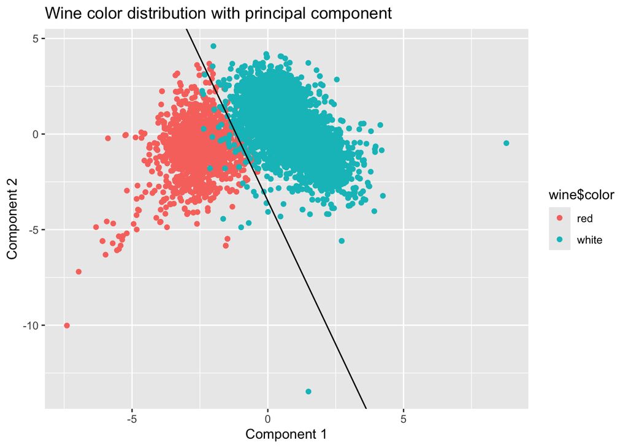

```r
qplot(scores[,1], scores[,2], color=wine$color)+labs(x='Component 1', y='Component 2', title = 'Wine color distribution with principal component')+ geom_abline(slope = -3, intercept = -3.5)
```

However, it is hard to distinguish wine quality from the principal components. It doesn’t show gradation, but various colors—that is, wines of different quality—are scattered around.

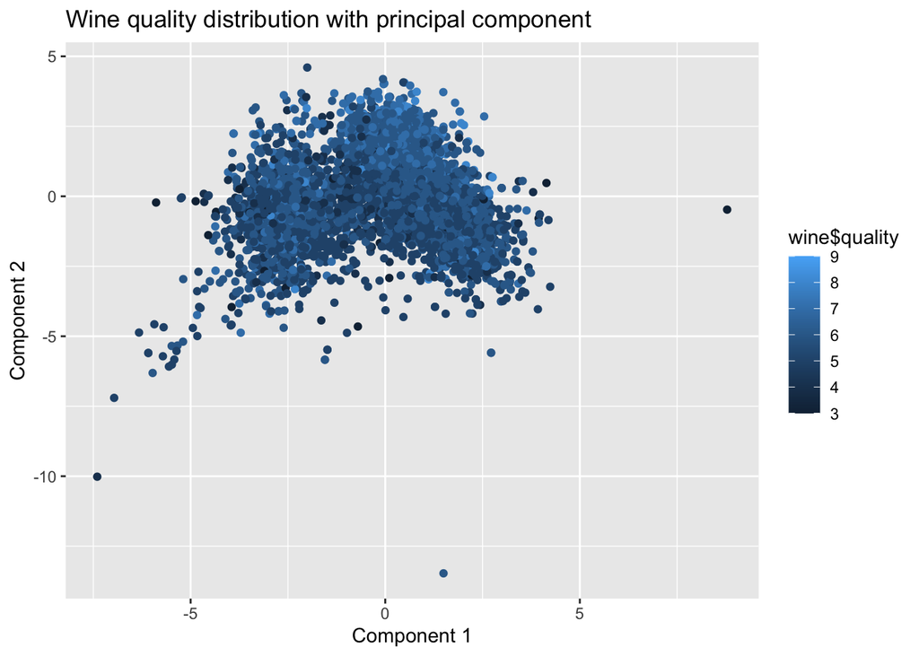

```r
qplot(scores[,1], scores[,2], color=wine$quality)+labs(x='Component 1', y='Component 2', title = 'Wine quality distribution with principal component')
```

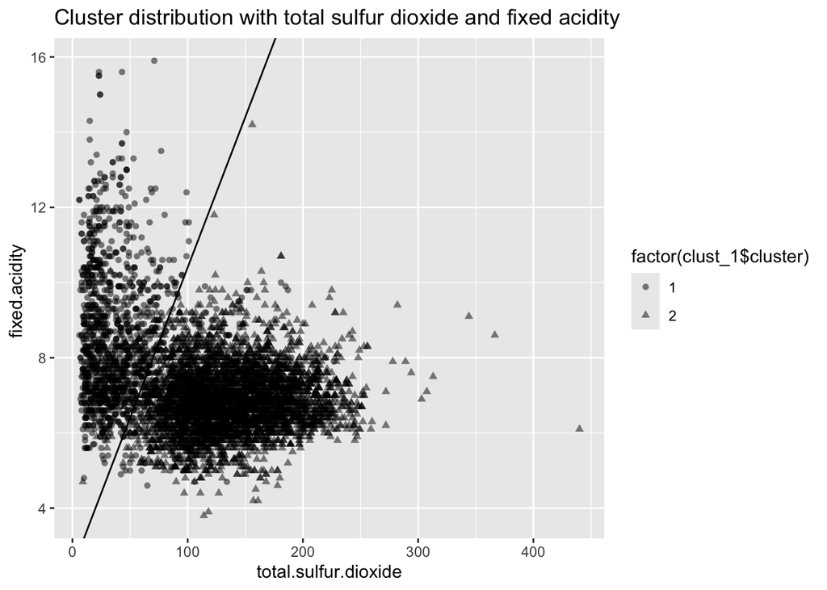

```r
# Extract the centers and scales from the rescaled data (which are named attributes)
mu = attr(X,"scaled:center")
sigma = attr(X,"scaled:scale")
# Run k-means with 2 clusters and 25 starts
clust_1 = kmeans(X, 2, nstart = 25)

# total.sulfur.dioxide and fixed.acidity
ggplot(wine) +
  geom_point(alpha = 0.5, aes(total.sulfur.dioxide, fixed.acidity, shape = factor(clust_1$cluster)))+
  labs(x ="total.sulfur.dioxide", y ="fixed.acidity ", title = "Cluster distribution with total sulfur dioxide and fixed acidity ")+ geom_abline(slope = 0.08, intercept = 2.4)
```

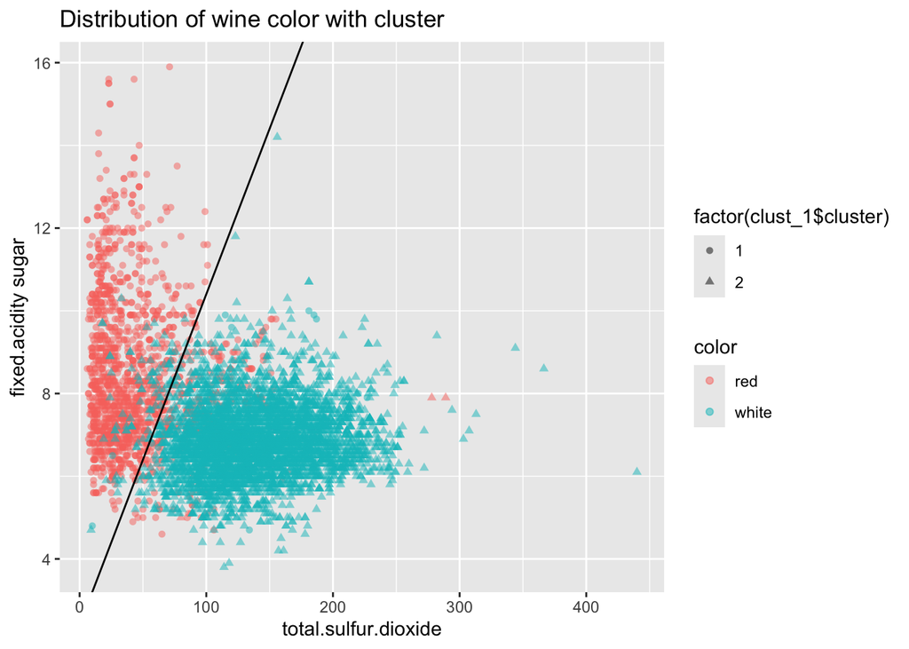

The plot below shows the distribution of wine quality, and it is so difficult to find any direction of color change that it is hard to distinguish the quality of wine.

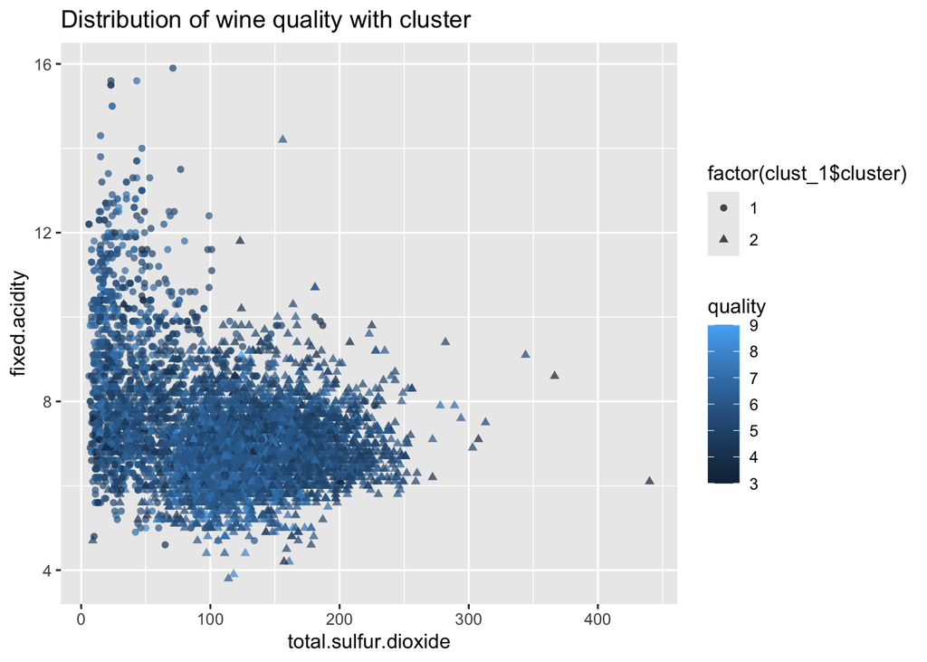

```r
ggplot(wine) +
  geom_point(alpha = 0.7, aes(total.sulfur.dioxide, fixed.acidity, color = quality, shape=factor(clust_1$cluster)))+
  labs( title = "Distribution of wine quality with cluster")
```

As a result, PCA is better at distinguishing the color of wine since it separates wines more clearly and with less overlap than k-means clustering. However, k-means is not bad at separating, so we can guess that the color of wine is closely related to the chemicals in the data. On the other hand, both PCA and K-men clustering are not capable of distinguishing the quality of wine.